# Sentiment Analysis

# Learning Objects

The primary goals of this tutorial includes:

> Introducing basic lexicon-based sentiment analysis in R

> Introducing conventional ML based SA in R

> Introducing DL based SA in R

# Lexicon-based SA

## We need to load some packages for use

```r
if (!requireNamespace("pacman")) install.packages('pacman')
library(pacman)
p_load(tidyverse,sentimentr, lexicon,syuzhet,parallel)
```

## Load sample data on earnings call transcripts

R tidyverse package provides a series of useful data wrangling tools. You can check it here https://www.tidyverse.org/.

We use earning call transcripts as an illustrative example. We mentioned that the QJE paper on firm level political risk is computed based on earnings call data. You can get their final dataset via https://www.firmlevelrisk.com/

We use some of these earnings call excerpts. It has already been parsed and it is structured by speaker-session. You can get the sample data via https://yongjunzhang.com/intro2css/assets/files/ect_sample.RData

```r
# load data
# load(url("https://yongjunzhang.com/files/css/ect_sample.RData"))
# you can also download the data and then load it
load("ect_sample.RData")
ect_sample <- ect_sample %>%
  filter(!is.na(tic))
```

```r
# Show a table for visual check
knitr::kable(ect_sample[1:10,],cap="Earnings call parsed data")
```

Earnings call parsed data

| SA_ID | speakerName | speakerTitle | text | tic |
| --- | --- | --- | --- | --- |
| 3125276 | Peter R. Huntsman | President_Chief Executive Officer & Director | Thank you. | HUN |
| 3499636 | Bill Griffiths | Chairman_President_CEO | Thank you. | NX |
| 3403385 | Ewout Steenbergen | Executive Vice President and Chief Financial Officer | Ryan, in general terms there is not a lot we can say at this point in time. We go through our normal procedures as we do every year during the third quarter. We do our internal studies, we supplement … | VOYA |
| 3434086 | Boyd Hoback | President & Chief Executive Officer | Thank you, Karen. Thank you all for joining us again. Appreciate your time. We’re real excited obviously about the progress we’re making on Bad Daddy’s and continued progress on Good Times. We look fo… | GTIM |
| 3399295 | Elizabeth Smith | Chairman and Chief Executive Officer | The first one is it will have full functionality. Release one will have the click-through seating, where am I on the waitlist, is my table ready and the ability to pay at the table. Released two, whic… | BLMN |
| 3185806 | Catherine Long | Chief Financial Officer_Treasurer & Executive VP | Good morning. | STOR |
| 3845316 | Ralph G. D’Ambrosio | Chief Financial Officer & Senior Vice President | Sure. So we expect the book-to-bill ratio in Electronic Systems and Communication Systems to be slightly above 1.0 for this year, and in Aerospace just under 1.0. Now, there’s a lot of opportunities, … | LLL |
| 2417295 | Mark Dankberg | Chairman of the Board_Chief Executive Officer | We are at the very front end of the commercial air part. So it is beginning to be more meaningful but not yet. But you are probably not far off. And the R&D thing, Shawn? | VSAT |
| 3930666 | Michael Dennis Casey | Carter’s_Inc. | Thanks, Rick. | CRI |
| 3610666 | Jerry Moyes | Founder_Chief Executive Officer | We agree that opportunity exists for margin expansion in all four of our operating segments. In our trucking segment, truck load dedicated in swift refrigerated. We believe we can improve margins even… | KNX |

## R syuzhet Package

Let us use *syuzhet* package as the baseline. Matthew Jockers created the syuzhet package that utilizes dictionary lookups for the Bing, NRC, and Afinn methods as well as a custom dictionary. He also utilizes a wrapper for the Stanford coreNLP which uses much more sophisticated analysis.

You can check here for a tutorial for syuzhet: https://cran.r-project.org/web/packages/syuzhet/vignettes/syuzhet-vignette.html

We are going to use its functions:

Some Notes:

- **afinn** is an English word list developed by Finn Nielsen. Words scores range from minus five (negative) to plus five (positive). You can download the original list via http://www2.imm.dtu.dk/pubdb/pubs/6010-full.html;
- **bing opinion lexicon** can be accessed via https://www.cs.uic.edu/~liub/FBS/sentiment-analysis.html;
- **nrc** is a list of English words and their associations with eight basic emotions (anger, fear, anticipation, trust, surprise, sadness, joy, and disgust) and two sentiments (negative and positive), and it can can be accessed via https://saifmohammad.com/WebPages/NRC-Emotion-Lexicon.htm

```r
# Let use tokenize our texts first
my_example_text <- ect_sample$text
s_v <- get_sentences(my_example_text)
head(s_v)
```

```
## [1] "Thank you."
## [2] "Thank you."
## [3] "Ryan, in general terms there is not a lot we can say at this point in time."
## [4] "We go through our normal procedures as we do every year during the third quarter."
## [5] "We do our internal studies, we supplement that with external studies, we get external and internal actuarial advice on that."
## [6] "Our auditors are involved, we look at economic assumptions, we look at actuarial assumptions, we look at policy holder behavioral assumptions and so on."
```

```r
syuzhet_vector <- get_sentiment(s_v, method="syuzhet")
head(syuzhet_vector)
```

```
## [1]  0.50  0.50  0.40  0.00  0.00 -0.25
```

Let us try different methods (use different lexicons)

```r
bing_vector <- get_sentiment(s_v, method="bing")
head(bing_vector)
```

```
## [1] 1 1 0 0 0 0
```

```r
afinn_vector <- get_sentiment(s_v, method="afinn")
head(afinn_vector)
```

```
## [1] 2 2 0 0 0 0
```

```r
nrc_vector <- get_sentiment(s_v, method="nrc", lang = "english")
head(nrc_vector)
```

```
## [1] 0 0 1 0 0 0
```

Let us compare the difference

```r
rbind(
  sign(head(syuzhet_vector)),
  sign(head(bing_vector)),
  sign(head(afinn_vector)),
  sign(head(nrc_vector))
)
```

```
##      [,1] [,2] [,3] [,4] [,5] [,6]
## [1,]    1    1    1    0    0   -1
## [2,]    1    1    0    0    0    0
## [3,]    1    1    0    0    0    0
## [4,]    0    0    1    0    0    0
```

Let us see get_nrc_sentiment results

```r
nrc_data <- get_nrc_sentiment(s_v)
angry_items <- which(nrc_data$anger > 0)
s_v[angry_items][1:10]
```

```
##  [1] "We're real excited obviously about the progress we're making on Bad Daddy's and continued progress on Good Times."
##  [2] "But we're not really beating our self up or anything about where we stand today."
##  [3] "We've deployed a fair amount of money in buybacks because we think it's a good buy and based on what our outlook is for cash flow and acquisition pipeline and timing of deals and where we want to be from a leverage standpoint, I don't think it's changed at all."
##  [4] "But, you got – the folks off the bench as Jack mentioned that hurt our gross margins in the first quarter but folks are on project and we changed our model a little bit in that – we are going to do a little bit plus bench moving forward for Q2 and Q3 and probably in the Q4 than we have up u…
##  [5] "We are way early in the process and I don't want to confuse anyone or scare anyone, right, that we are going to change the counseling because that's not the plan."
##  [6] "I expect that to be a bit of synergy there that given our SG&A model versus most of our peers but nothing on the side in recruiting side."
##  [7] "We also had strong product expansion with the on-demand service going live, NSX service, hybrid networking."
##  [8] "Well, I think that something that management is going to decide depending on what type of pickup and demand we see and the type of margins we're going to see."
##  [9] "I think that this is an area that we feel we could generate cash and that won't be an incremental expenses."
## [10] "And then the other thing that plays into it of course, with being on a cash basis for more than half of our revenue is the timing of reimbursement one quarter versus the next."
```

```r
joy_items <- which(nrc_data$joy > 0)
s_v[joy_items][1:10]
```

```
##  [1] "We're real excited obviously about the progress we're making on Bad Daddy's and continued progress on Good Times."
##  [2] "Release one will have the click-through seating, where am I on the waitlist, is my table ready and the ability to pay at the table."
##  [3] "Good morning."
##  [4] "We believe we can improve margins even in a soft break environment as we hyper focus like never before on utilization, improved safety and increased driver retention."
##  [5] "In our intermodal segment margins should improve as we continue to work to fill the existing container fleet and meet our turn objectives of two turns a month."
##  [6] "Reaching these levels of turns will significantly improve our chassis and dray costs and as a result create opportunities to expand our intermodal margins."
##  [7] "Good, good to hear your voice."
##  [8] "We're happy with our offering."
##  [9] "So big focus, top priority, and we're making good progress."
## [10] "With respect to pricing of those types of assets, I don't really have any comment on that."
```

```r
valence <- (nrc_data[, 9]*-1) + nrc_data[, 10]
valence[1:10]
```

```
##  [1] 0 0 1 0 0 0 0 0 0 0
```

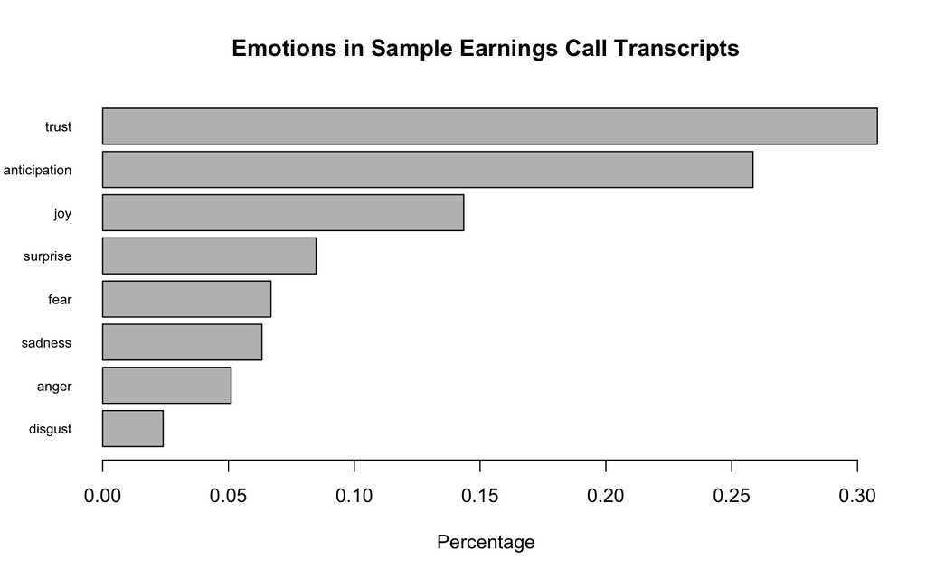

```r
barplot(
  sort(colSums(prop.table(nrc_data[, 1:8]))),
  horiz = TRUE,
  cex.names = 0.7,
  las = 1,
  main = "Emotions in Sample Earnings Call Transcripts", xlab="Percentage"
  )
```

You can also customize your lexicons

```r
my_text <- "I love when I see something beautiful.  I hate it when ugly feelings creep into my head."
char_v <- get_sentences(my_text)
method <- "custom"
custom_lexicon <- data.frame(word=c("love", "hate", "beautiful", "ugly"), value=c(1,-1,1, -1))
my_custom_values <- get_sentiment(char_v, method = method, lexicon = custom_lexicon)
my_custom_values
```

```
## [1]  2 -2
```

## Let Us Move to sentimentR package

YZ’s comment: because the Syuzhet package does not account for negation and valence shifter. I typically use sentimentr as the default package for sentiment analysis in R. Note that sentimentr use some functions from Syuzhet, for instance, `get_sentences()`.

Another R package that deal with valen shifter is https://cran.r-project.org/web/packages/vader/vader.pdf. You can use the function `get_vader()`.

This tutorial is based on **Tyler Rinke**’s amazing one: https://github.com/trinker/sentimentr

-> sentimentr attempts to take into account valence shifters (i.e., negators, amplifiers (intensifiers), de-amplifiers (downtoners), and adversative conjunctions) while maintaining speed. Simply put, sentimentr is an augmented dictionary lookup. The next questions address why it matters.

-> A negator flips the sign of a polarized word (e.g., “I do not like it.”). See lexicon::hash_valence_shifters[y==1] for examples. An amplifier (intensifier) increases the impact of a polarized word (e.g., “I really like it.”). See lexicon::hash_valence_shifters[y==2] for examples. A de-amplifier (downtoner) reduces the impact of a polarized word (e.g., “I hardly like it.”). See lexicon::hash_valence_shifters[y==3] for examples. An adversative conjunction overrules the previous clause containing a polarized word (e.g., “I like it but it’s not worth it.”). See lexicon::hash_valence_shifters[y==4] for examples.

### Functions

There are two main functions (top 2 in table below) in **sentimentr** with several helper functions summarized in the table below:

| Function | Description |
| --- | --- |
| `sentiment` | Sentiment at the sentence level |
| `sentiment_by` | Aggregated sentiment by group(s) |
| `profanity` | Profanity at the sentence level |
| `profanity_by` | Aggregated profanity by group(s) |
| `emotion` | Emotion at the sentence level |
| `emotion_by` | Aggregated emotion by group(s) |
| `uncombine` | Extract sentence level sentiment from `sentiment_by` |
| `get_sentences` | Regex based string to sentence parser (or get sentences from `sentiment`/`sentiment_by`) |
| `replace_emoji` | repalcement |
| `replace_emoticon` | Replace emoticons with word equivalent |
| `replace_grade` | Replace grades (e.g., “A+”) with word equivalent |
| `replace_internet_slang` | replacment |
| `replace_rating` | Replace ratings (e.g., “10 out of 10”, “3 stars”) with word equivalent |
| `as_key` | Coerce a `data.frame` lexicon to a polarity hash key |
| `is_key` | Check if an object is a hash key |
| `update_key` | Add/remove terms to/from a hash key |
| `highlight` | Highlight positive/negative sentences as an HTML document |
| `general_rescale` | Generalized rescaling function to rescale sentiment scoring |
| `sentiment_attribute` | Extract the sentiment based attributes from a text |
| `validate_sentiment` | Validate sentiment score sign against known results |

### The Equation

The equation below describes the augmented dictionary method of **sentimentr** that may give better results than a simple lookup dictionary approach that does not consider valence shifters. The equation used by the algorithm to assign value to polarity of each sentence fist utilizes a sentiment dictionary (e.g., Jockers, [(2017)](https://github.com/mjockers/syuzhet)) to tag polarized words. Each paragraph ($p_i = \{s_1, s_2, ..., s_n\}$) composed of sentences, is broken into element sentences ($s_i,j = \{w_1, w_2, ..., w_n\}$) where $w$ are the words within sentences. Each sentence ($s_j$) is broken into a an ordered bag of words. Punctuation is removed with the exception of pause punctuations (commas, colons, semicolons) which are considered a word within the sentence. I will denote pause words as $cw$ (comma words) for convenience. We can represent these words as an i,j,k notation as $w_{i,j,k}$. For example $w_{3,2,5}$ would be the fifth word of the second sentence of the third paragraph. While I use the term paragraph this merely represent a complete turn of talk. For example it may be a cell level response in a questionnaire composed of sentences.

The words in each sentence ($w_{i,j,k}$) are searched and compared to a dictionary of polarized words (e.g., a combined and augmented version of Jocker’s (2017) [originally exported by the [**syuzhet**](https://github.com/mjockers/syuzhet) package] & Rinker’s augmented Hu & Liu (2004) dictionaries in the [**lexicon**](https://cran.r-project.org/package=lexicon) package). Positive ($w_{i,j,k}^{+}$) and negative ($w_{i,j,k}^{-}$) words are tagged with a $+1$ and $-1$ respectively (or other positive/negative weighting if the user provides the sentiment dictionary). I will denote polarized words as $pw$ for convenience. These will form a polar cluster ($c_{i,j,l}$) which is a subset of the a sentence ($c_{i,j,l} \subseteq s_i,j$).

The polarized context cluster ($c_{i,j,l}$) of words is pulled from around the polarized word ($pw$) and defaults to 4 words before and two words after $pw$ to be considered as valence shifters. The cluster can be represented as ($c_{i,j,l} = \{pw_{i,j,k - nb}, ..., pw_{i,j,k} , ..., pw_{i,j,k - na}\}$), where $nb$ & $na$ are the parameters `n.before` and `n.after` set by the user. The words in this polarized context cluster are tagged as neutral ($w_{i,j,k}^{0}$), negator ($w_{i,j,k}^{n}$), amplifier [intensifier] ($w_{i,j,k}^{a}$), or de-amplifier [downtoner] ($w_{i,j,k}^{d}$). Neutral words hold no value in the equation but do affect word count ($n$). Each polarized word is then weighted ($w$) based on the weights from the `polarity_dt` argument and then further weighted by the function and number of the valence shifters directly surrounding the positive or negative word ($pw$). Pause ($cw$) locations (punctuation that denotes a pause including commas, colons, and semicolons) are indexed and considered in calculating the upper and lower bounds in the polarized context cluster. This is because these marks indicate a change in thought and words prior are not necessarily connected with words after these punctuation marks. The lower bound of the polarized context cluster is constrained to $\max \{pw_{i,j,k - nb}, 1, \max \{cw_{i,j,k} < pw_{i,j,k}\}\}$ and the upper bound is constrained to $\min \{pw_{i,j,k + na}, w_{i,jn}, \min \{cw_{i,j,k} > pw_{i,j,k}\}\}$ where $w_{i,jn}$ is the number of words in the sentence.

The core value in the cluster, the polarized word is acted upon by valence shifters. Amplifiers increase the polarity by 1.8 (.8 is the default weight ($z$)). Amplifiers ($w_{i,j,k}^{a}$) become de-amplifiers if the context cluster contains an odd number of negators ($w_{i,j,k}^{n}$). De-amplifiers work to decrease the polarity. Negation ($w_{i,j,k}^{n}$) acts on amplifiers/de-amplifiers as discussed but also flip the sign of the polarized word. Negation is determined by raising $-1$ to the power of the number of negators ($w_{i,j,k}^{n}$) plus $2$. Simply, this is a result of a belief that two negatives equal a positive, 3 negatives a negative, and so on.

The adversative conjunctions (i.e., ‘but’, ‘however’, and ‘although’) also weight the context cluster. An adversative conjunction before the polarized word ($w_{adversative\,conjunction}, ..., w_{i, j, k}^{p}$) up-weights the cluster by 1 + $z_2 * \{|w_{adversative\,conjunction}|, ..., w_{i, j, k}^{p}\}$ (.85 is the default weight ($z_2$) where $|w_{adversative\,conjunction}|$ are the number of adversative conjunctions before the polarized word). An adversative conjunction after the polarized word down-weights the cluster by 1 + $\{w_{i, j, k}^{p}, ..., |w_{adversative\,conjunction}| * -1\} * z_2$. This corresponds to the belief that an adversative conjunction makes the next clause of greater values while lowering the value placed on the prior clause.

The researcher may provide a weight ($z$) to be utilized with amplifiers/de-amplifiers (default is $.8$; de-amplifier weight is constrained to $-1$ lower bound). Last, these weighted context clusters ($c_{i,j,l}$) are summed ($c'_{i,j}$) and divided by the square root of the word count (√$w_{i,jn}$) yielding an **unbounded polarity score** ($\delta_{i,j}$) for each sentence.

$\delta$<sub>*i**j***</sub> = *c*’<sub>ij</sub>/√*w*<sub>*i**j**n*</sub>

Where:

$$c'_{i,j} = \sum{((1 + w_{amp} +
w_{deamp})\cdot w_{i,j,k}^{p}(-1)^{2 + w_{neg}})}$$

$$w_{amp} = \sum{(w_{neg}\cdot (z \cdot
w_{i,j,k}^{a}))}$$

$$w_{deamp} = \max(w_{deamp'},
-1)$$

$$w_{deamp'} = \sum{(z(- w_{neg}\cdot
w_{i,j,k}^{a} + w_{i,j,k}^{d}))}$$

$$w_{b} = 1 + z_2 *
w_{b'}$$

$$w_{b'} =
\sum{(|w_{adversative\,conjunction}|, ..., w_{i, j, k}^{p}, w_{i, j,
k}^{p}, ..., |w_{adversative\,conjunction}| * -1})$$

$w_{neg}$ = ($\sum{w_{i,j,k}^{n}}$ ) mod 2

To get the mean of all sentences ($s_{i,j}$) within a paragraph/turn of talk ($p_{i}$) simply take the average sentiment score $p_{i,\delta_{i,j}}$ = 1/n $\cdot$ $\sum$ $\delta_{i,j}$ or use an available weighted average (the default `average_weighted_mixed_sentiment` which upweights the negative values in a vector while also downweighting the zeros in a vector or `average_downweighted_zero` which simply downweights the zero polarity scores).

## Preferred Workflow

Here is a basic `sentiment` demo. Notice that the first thing you should do is to split your text data into sentences (a process called sentence boundary disambiguation) via the `get_sentences` function. This can be handled within `sentiment` (i.e., you can pass a raw character vector) but it slows the function down and should be done one time rather than every time the function is called. Additionally, a warning will be thrown if a larger raw character vector is passed. The preferred workflow is to spit the text into sentences with `get_sentences` before any sentiment analysis is done.

```r
mytext <- c(
    'do you like it?  But I hate really bad dogs',
    'I am the best friend.',
    'Do you really like it?  I\'m not a fan'
)
mytext <- get_sentences(mytext)
sentiment(mytext)
```

```
##    element_id sentence_id word_count  sentiment
## 1:          1           1          4  0.2500000
## 2:          2           1          6 -1.8677359
## 3:          3           1          5  0.5813777
## 4:          4           1          5  0.4024922
## 5:          5           1          4  0.0000000
```

To aggregate by element (column cell or vector element) use `sentiment_by` with `by = NULL`.

```r
mytext <- c(
    'do you like it?  But I hate really bad dogs',
    'I am the best friend.',
    'Do you really like it?  I\'m not a fan'
)
mytext <- get_sentences(mytext)
sentiment_by(mytext)
```

```
##    element_id word_count sd ave_sentiment
## 1:          1          4 NA     0.2500000
## 2:          2          6 NA    -1.8677359
## 3:          3          5 NA     0.5813777
## 4:          4          5 NA     0.4024922
## 5:          5          4 NA     0.0000000
```

To aggregate by grouping variables use `sentiment_by` using the `by` argument.

```r
out <- with(
    ect_sample,
    sentiment_by(
        get_sentences(text),
        list(tic)
    )
)
head(out)
```

```
##     tic word_count        sd ave_sentiment
## 1: <NA>     126209 0.2727835     0.2363563
## 2:    A         35        NA     0.8062772
## 3: AACC         28 0.1961161     0.1513462
## 4:  AAI         15        NA     0.2065591
## 5:  AAL         11        NA     0.0000000
## 6: AAON         66        NA    -0.1169369
```

### Plotting at Aggregated Sentiment

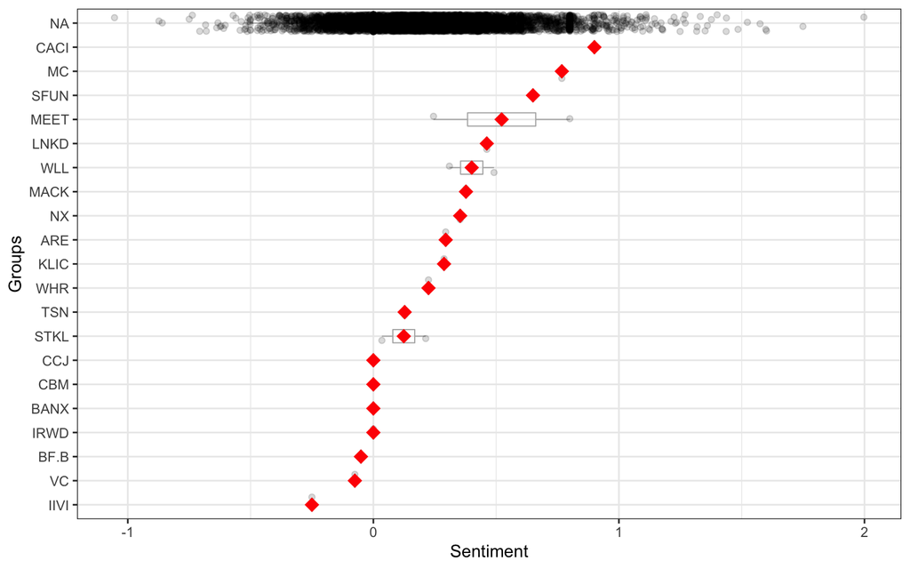

```r
# let us plot random 20 companies
out_20 <- sample_n(out,20)
plot(out_20)
```

### You can Use the Custimized Dictionary as well

Because earnings call transcripts relate to financial domain, we use financial specific dictionary.

```r
out <- with(
    ect_sample,
    sentiment_by(get_sentences(text),
                 polarity_dt=lexicon::hash_sentiment_loughran_mcdonald,
                 list(tic))
    )
```

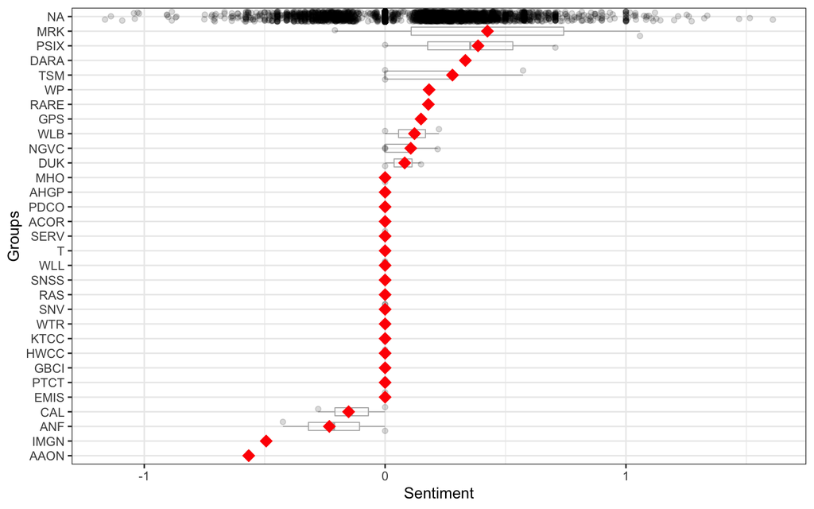

```r
plot(sample_n(out,30))
```

### Plotting at the Sentence Level

The `plot` method for the class `sentiment` uses **syuzhet**’s `get_transformed_values` combined with **ggplot2** to make a reasonable, smoothed plot for the duration of the text based on percentage, allowing for comparison between plots of different texts. This plot gives the overall shape of the text’s sentiment. The user can see `syuzhet::get_transformed_values` for more details.

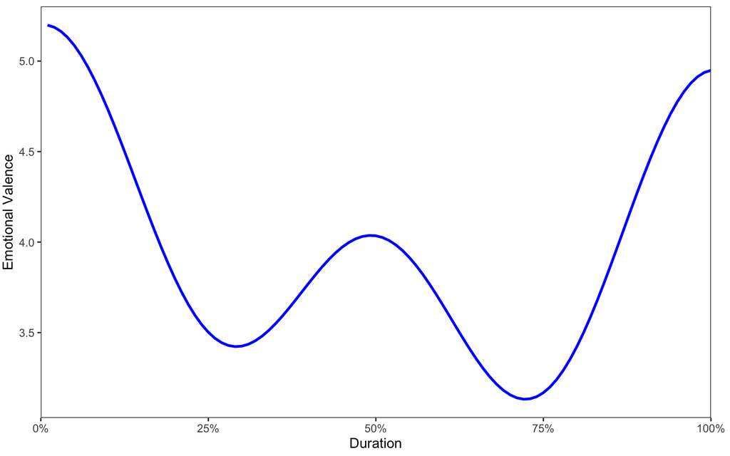

```r
plot(uncombine(sample_n(out,30)))
```

# Conventional ML based SA

> On top of lexicon-based methods, you can also use supervised machine learning methods to implement sentiment analysis if you have a training dataset or you can find a pretrained model that fits into your research purpose appropriately.

> The basic idea is very straightforward. You need to do some feature engineering to obtain a list of features used to classify sentiments (e.g., positive, negative, or neutral). So you can treat this as a classification problem.

> One option is to use n-gram as your feature matrix and then train a classifier using quanteda package in R or you can also use caret pacakge as we have covered in previous lab session.

> We will use IMDb Movie Review as an illustrative example. The IMDb Movie Reviews dataset is a binary sentiment analysis dataset consisting of 50,000 reviews from the Internet Movie Database (IMDb) labeled as positive or negative. The dataset contains an even number of positive and negative reviews. Only highly polarizing reviews are considered. A negative review has a score ≤ 4 out of 10, and a positive review has a score ≥ 7 out of 10. No more than 30 reviews are included per movie. The dataset contains additional unlabeled data. https://paperswithcode.com/dataset/imdb-movie-reviews. We will use the toy dataset from quanteda’s data_corpus_moviereviews.. You can check this tutorial https://tutorials.quanteda.io/machine-learning/nb/

```r
p_load(quanteda,quanteda.textmodels,caret)
corp_movies <- data_corpus_moviereviews
summary(corp_movies, 10)
```

```
## Corpus consisting of 2000 documents, showing 10 documents:
##
##             Text Types Tokens Sentences sentiment   id1   id2
##  cv000_29416.txt   354    841         9       neg cv000 29416
##  cv001_19502.txt   156    278         1       neg cv001 19502
##  cv002_17424.txt   276    553         3       neg cv002 17424
##  cv003_12683.txt   313    555         2       neg cv003 12683
##  cv004_12641.txt   380    841         2       neg cv004 12641
##  cv005_29357.txt   328    747         1       neg cv005 29357
##  cv006_17022.txt   331    641         5       neg cv006 17022
##   cv007_4992.txt   325    673         6       neg cv007  4992
##  cv008_29326.txt   441    794        10       neg cv008 29326
##  cv009_29417.txt   401    965        23       neg cv009 29417
```

### Let us take a look at imdb movie review data first

```r
table(corp_movies$sentiment)
```

```
##
##  neg  pos
## 1000 1000
```

```r
# generate 1500 numbers without replacement
set.seed(300)
id_train <- sample(1:2000, 1500, replace = FALSE)
head(id_train, 10)
```

```
##  [1]  590  874 1602  985 1692  789  553 1980 1875 1705
```

```r
# create docvar with ID
corp_movies$id_numeric <- 1:ndoc(corp_movies)

# tokenize texts
toks_movies <- tokens(corp_movies, remove_punct = TRUE, remove_number = TRUE) %>%
               tokens_remove(pattern = stopwords("en")) %>%
               tokens_wordstem()
dfmt_movie <- dfm(toks_movies)

# get training set
dfmat_training <- dfm_subset(dfmt_movie, id_numeric %in% id_train)

# get test set (documents not in id_train)
dfmat_test <- dfm_subset(dfmt_movie, !id_numeric %in% id_train)

# Next we train the naive Bayes classifier using textmodel_nb().

tmod_nb <- textmodel_nb(dfmat_training, dfmat_training$sentiment)
summary(tmod_nb)
```

```
##
## Call:
## textmodel_nb.dfm(x = dfmat_training, y = dfmat_training$sentiment)
##
## Class Priors:
## (showing first 2 elements)
## neg pos
## 0.5 0.5
##
## Estimated Feature Scores:
##         plot      two      teen     coupl       go    church     parti
## neg 0.002579 0.002318 0.0002870 0.0007157 0.002663 8.719e-05 0.0002652
## pos 0.001507 0.002338 0.0001656 0.0005456 0.002348 8.768e-05 0.0002728
##         drink     drive      get     accid      one       guy       die
## neg 1.199e-04 0.0003052 0.004487 9.446e-05 0.007389 0.0014459 0.0005486
## pos 9.418e-05 0.0002630 0.003783 1.851e-04 0.007355 0.0009937 0.0005488
##     girlfriend   continu      see     life  nightmar      deal    watch
## neg  0.0003124 0.0003161 0.002558 0.001435 0.0001199 0.0004323 0.001642
## pos  0.0002338 0.0003215 0.003020 0.002497 0.0001202 0.0005196 0.001539
##         movi     sorta     find   critiqu mind-fuck   generat     touch
## neg 0.010118 1.090e-05 0.001453 9.446e-05 3.633e-06 0.0002652 0.0002289
## pos 0.007657 1.624e-05 0.001630 8.443e-05 3.247e-06 0.0002923 0.0004449
##          cool      idea
## neg 0.0003052 0.0008210
## pos 0.0002273 0.0005845
```

```r
# Naive Bayes can only take features into consideration that occur both in the training set and the test set, but we can make the features identical using dfm_match()

dfmat_matched <- dfm_match(dfmat_test, features = featnames(dfmat_training))

# Let’s inspect how well the classification worked.

actual_class <- dfmat_matched$sentiment
predicted_class <- predict(tmod_nb, newdata = dfmat_matched)
tab_class <- table(actual_class, predicted_class)
tab_class
```

```
##             predicted_class
## actual_class neg pos
##          neg 213  45
##          pos  37 205
```

```r
# We can use the function confusionMatrix() from the caret package to assess the performance of the classification.

confusionMatrix(tab_class, mode = "everything")
```

```
## Confusion Matrix and Statistics
##
##             predicted_class
## actual_class neg pos
##          neg 213  45
##          pos  37 205
##
##                Accuracy : 0.836
##                  95% CI : (0.8006, 0.8674)
##     No Information Rate : 0.5
##     P-Value [Acc > NIR] : <2e-16
##
##                   Kappa : 0.672
##
##  Mcnemar's Test P-Value : 0.4395
##
##             Sensitivity : 0.8520
##             Specificity : 0.8200
##          Pos Pred Value : 0.8256
##          Neg Pred Value : 0.8471
##               Precision : 0.8256
##                  Recall : 0.8520
##                      F1 : 0.8386
##              Prevalence : 0.5000
##          Detection Rate : 0.4260
##    Detection Prevalence : 0.5160
##       Balanced Accuracy : 0.8360
##
##        'Positive' Class : neg
##
```

Of course, you can achieve this just using caret package as well.

# Deep Learning based SA

The following part introduces a simple DNN. You can get the original post via https://tensorflow.rstudio.com/guide/keras/examples/imdb_fasttext/. You can also check another tutorial via https://burtmonroe.github.io/TextAsDataCourse/Tutorials/TADA-IntroToKerasAndTensflowInR.nb.html

```r
library(keras)
library(purrr)

# Function Definitions ----------------------------------------------------

create_ngram_set <- function(input_list, ngram_value = 2){
  indices <- map(0:(length(input_list) - ngram_value), ~1:ngram_value + .x)
  indices %>%
    map_chr(~input_list[.x] %>% paste(collapse = "|")) %>%
    unique()
}

add_ngram <- function(sequences, token_indice, ngram_range = 2){
  ngrams <- map(
    sequences,
    create_ngram_set, ngram_value = ngram_range
  )

  seqs <- map2(sequences, ngrams, function(x, y){
    tokens <- token_indice$token[token_indice$ngrams %in% y]
    c(x, tokens)
  })

  seqs
}


# Parameters --------------------------------------------------------------

# ngram_range = 2 will add bi-grams features
ngram_range <- 2
max_features <- 20000
maxlen <- 400
batch_size <- 32
embedding_dims <- 50
epochs <- 5
```

```r
# Data Preparation --------------------------------------------------------

# Load data
imdb_data <- dataset_imdb(num_words = max_features)
```

```
## Loaded Tensorflow version 2.3.1
```

```r
# Train sequences
print(length(imdb_data$train$x))
```

```
## [1] 25000
```

```r
print(sprintf("Average train sequence length: %f", mean(map_int(imdb_data$train$x, length))))
```

```
## [1] "Average train sequence length: 238.713640"
```

```r
# Test sequences
print(length(imdb_data$test$x))
```

```
## [1] 25000
```

```r
print(sprintf("Average test sequence length: %f", mean(map_int(imdb_data$test$x, length))))
```

```
## [1] "Average test sequence length: 230.804200"
```

```r
if(ngram_range > 1) {

  # Create set of unique n-gram from the training set.
  ngrams <- imdb_data$train$x %>%
    map(create_ngram_set) %>%
    unlist() %>%
    unique()

  # Dictionary mapping n-gram token to a unique integer
    # Integer values are greater than max_features in order
    # to avoid collision with existing features
  token_indice <- data.frame(
    ngrams = ngrams,
    token  = 1:length(ngrams) + (max_features),
    stringsAsFactors = FALSE
  )

  # max_features is the highest integer that could be found in the dataset
  max_features <- max(token_indice$token) + 1

  # Augmenting x_train and x_test with n-grams features
  imdb_data$train$x <- add_ngram(imdb_data$train$x, token_indice, ngram_range)
  imdb_data$test$x <- add_ngram(imdb_data$test$x, token_indice, ngram_range)
}

# Pad sequences
imdb_data$train$x <- pad_sequences(imdb_data$train$x, maxlen = maxlen)
imdb_data$test$x <- pad_sequences(imdb_data$test$x, maxlen = maxlen)
```

```r
# Model Definition --------------------------------------------------------

model <- keras_model_sequential()

model %>%
  layer_embedding(
    input_dim = max_features, output_dim = embedding_dims,
    input_length = maxlen
    ) %>%
  layer_global_average_pooling_1d() %>%
  layer_dense(1, activation = "sigmoid")

model %>% compile(
  loss = "binary_crossentropy",
  optimizer = "adam",
  metrics = "accuracy"
)

# Fitting -----------------------------------------------------------------

model %>% fit(
  imdb_data$train$x, imdb_data$train$y,
  batch_size = batch_size,
  epochs = epochs,
  verbose = 2,
  validation_data = list(imdb_data$test$x, imdb_data$test$y)
)
```

### YOU can also try to figure out how to use bert model. I do not see some good practices in terms of training bert model in R using tensorflow and keras. But definitely you should try it in python.